# Introduction

Daniel Arribas-Bel & Thomas de Graaff

September 5, 2014

# Introduction

# *Why* this workshop?

- In the *social sciences* few attention to what tools to use (and why they make sense)
- Increasing *need* for/in openness & transparancy
  - from journals, universities and governments
  - increase in cooperation (over wider distances)
  - access to your own files
  - make yourself more visible
- Why *we* want to give this workshop
  - intrinsic interest
  - our goal: pre-conferences workshops / courses

# What we want (and don’t want) with this workshop

- We are mostly interested in the principles behind a good open (scientific) workflow, aware of the facts that
  - there is no final, optimal, set of workflow tools
  - investment is very, very costly
- However, being a practical workshop we do
  - work with a specific set of tools (markdown, R, RStudio, git) which
  - enables us *in this workshop* to make a paper reproducable and open

# Related work

- Inspired by Kieran Healey’s (associate professor in sociology) work: [Choosing your Workflow Applications](http://kieranhealy.org/files/misc/workflow-apps.pdf)
- Courses for reproducable research seems to pop up everywhere (but mostly in datascience courses):
  - Datascience course: https://www.coursera.org/
  - Tools for Reproducible Research http://kbroman.org/Tools4RR/

# Workflow

# Open?

- Workflow: *Progression of steps (tasks, events, interactions) that comprise a work process, involve two or more persons, and create or add value to the organization’s activities* ([BusinessDictionary](http://www.businessdictionary.com/definition/workflow.html))
- Open workflow: One that enhances *transparency*, *collaboration* and *reproducibility*

# Research cycle

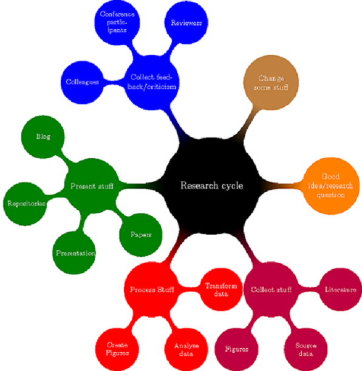

# Why bother about a workflow or tools?

- Good scientific practice: *document how you have achieved your results*; this ensures
  - Reproducibility
  - Transparency
  - Modularity
  - Portability (across systems and users)
  - Efficiency
  - Self-sanity

# Why should it be open?

- Open Science
- Reproducibility
- Transparency
- Modularity
- Portability (across systems and users)
- Efficiency
- Visibility

# When should I adopt an open reproducable workflow?

- The sooner the better
- But think twice about which one (switching is costly)
- Start one step at a time

*A journey of a thousand miles begins with a single step*

Lao-tzu

# Reproducability

# In general

> In science consensus is irrelevant. What is relevant is reproducible results. The greatest scientists in history are great precisely because they broke with the consensus (Michael Crichton)

# In computation science:

> The data and code used to make a finding are available and they are sufficient for an independent researcher to recreate the finding (Peng, 2011)
- Literature programming (Donald E. Knuth, 1984):
  - weaving of **code**, **documentation** and **output** (articles, presentations, websites)

# In the social sciences?

- Complete reproducability often not feasible
  - qualitative research
  - propietary data (?)
- but you can come a long way, especially with
  - theoretical work
  - quantitative (e.g., statistical or simulation) work
- Goal should be more to make your research as reproducable *as possible*

# Code, documentation and output

1. Synonyms
2. All based on text files
3. Encompasses almost anything
   - data itself
   - set of commands for data cleaning and statistical analysis
   - database with references
   - transcript of interviews
   - text for aticles, presentations or websites
4. Only output is displayed/interpreted differently (e.g., in a browser or pdf viewer)

# Our goal (not being ambitious)

What we want is that with *one single* command we

- read in and transform our data
- run the analysis
- create output (tables and figures)
- combine output with text and references
- create presentation material (paper, slides, webpages) and
- publish presentation material on an open repository

This all under a full fledged versioning control system

# Tools for reproducability

- Markup lanaguages
  - Markdown
  - LaTeX
  - HTML
- Terminal tools (GNU make, diff, pandoc)
- Versioning system (Git & VCN)
- Reference manager (bibdesk/Mendeley)

# Tools for reproducability (cnt.)

- Statistical software (pure command line driven): Python and R
- Environments
  - [R](http://www.rproject.org/) and [RStudio](http://www.rstudio.com) environment
  - Python and [iPython notebook](http://ipython.org/notebook.html) environment
  - Python and [Sumatra](http://neuralensemble.org/sumatra)
  - Emacs [org mode](http://orgmode.org/)

# Tools for openness

- Repositories:
  - Github (host webpages as well)
  - Bitbucket
- R packages http://cran.r-project.org/
- iPython notebook viewer http://nbviewer.ipython.org/

# Examples

*Reproducible Research with R and RStudio* Book1

- https://github.com/christophergandrud/Rep-Res-Book

Amsterdam paper example using ipython notebook:

- http://darribas.org/buzz_adam

# What we use in this workshop

1. R and RStudio (with Yihui Xie’s `knitr` package)
2. Markdown language
3. Bibdesk/Mendeley
4. Git and Github
5. GNU make

Only implicitly we make use of LaTeX, BibTex, HTML and pandoc (all under the hood of RStudio)

# Schedule

# Schedule Day 1 - Friday Sept. 5th

- **[9am-12am]** Introduction
  - Concepts behind open workflows/Overview of tools
  - Install session

[Lunch]

- **[1pm-3pm]** Version control and task automation
  - Terminal/git/make

[Break]

- **[3:30pm-5:30pm]** Typesetting
  - Markdown/LaTeX/bibtex/pandoc/RStudion

[Diner]

- Location and time: To be announced

# Schedule Day 2 - Saturday Sept. 6th.

- **[9am-11am]** Data analysis
  - R

[break]

- **[11:30am-1pm]** Publishing
  - Slides
  - Publishing on GitHub
  - Other publication channels

[Lunch]

# In conclusion

# Loose ends…

- Questions?

This workshop is financially supported by FOSTER.